# Analysis and Visualizations for Detection of Fraudulent Transaction in Financial Service Payments

### Report by: Satwik Mishrta

# Section 1: General Statistical Analysis

The table below describes the mean, standad deviation abd the quartiles. Moreover check for null value was also done, which retuned false (no null values).

|  | step | amount | oldbalanceOrg | newbalanceOrig | oldbalanceDest | newbalanceDest | isFraud | isFlaggedFraud |
| --- | --- | --- | --- | --- | --- | --- | --- | --- |
| count | 6.362620e+06 | 6.362620e+06 | 6.362620e+06 | 6.362620e+06 | 6.362620e+06 | 6.362620e+06 | 6.362620e+06 | 6.362620e+06 |
| mean | 2.433972e+02 | 1.798619e+05 | 8.338831e+05 | 8.551137e+05 | 1.100702e+06 | 1.224996e+06 | 1.290820e-03 | 2.514687e-06 |
| std | 1.423320e+02 | 6.038582e+05 | 2.888243e+06 | 2.924049e+06 | 3.399180e+06 | 3.674129e+06 | 3.590480e-02 | 1.585775e-03 |
| min | 1.000000e+00 | 0.000000e+00 | 0.000000e+00 | 0.000000e+00 | 0.000000e+00 | 0.000000e+00 | 0.000000e+00 | 0.000000e+00 |
| 25% | 1.560000e+02 | 1.338957e+04 | 0.000000e+00 | 0.000000e+00 | 0.000000e+00 | 0.000000e+00 | 0.000000e+00 | 0.000000e+00 |
| 50% | 2.390000e+02 | 7.487194e+04 | 1.420800e+04 | 0.000000e+00 | 1.327057e+05 | 2.146614e+05 | 0.000000e+00 | 0.000000e+00 |
| 75% | 3.350000e+02 | 2.087215e+05 | 1.073152e+05 | 1.442584e+05 | 9.430367e+05 | 1.111909e+06 | 0.000000e+00 | 0.000000e+00 |
| max | 7.430000e+02 | 9.244552e+07 | 5.958504e+07 | 4.958504e+07 | 3.560159e+08 | 3.561793e+08 | 1.000000e+00 | 1.000000e+00 |

In the bar graph, below we can see that the data is highly imbalanced. I have worked on insurance fraudulent claims data and had realized back then that artificial synthesis of data points to oversample, or undersample although is an option but doesn't generalize well. On the other hand, balancing class weights, which means penalizing the classifier more if it falsely classifies into the majority class if done well could lead to better results. In the table below, 0 indicates non-fraud, i.e. close to 6.3 million transactions as compared to only `8213` fraudulent transactions. Percentage of the fraudulent and non-fraudulent transactions is `0.13%, 99.87%` respectively

```
0    6354407
1       8213
Name: isFraud, dtype: int64
```

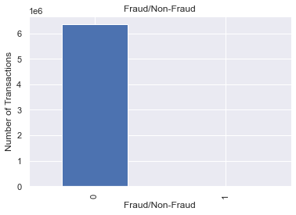

# Section 2: Transaction Types Analysis

Observations:

1. Majority of the transaction are of type CASH_OUT followed by PAYMENT. TRANSFER and DEBIT are the least.

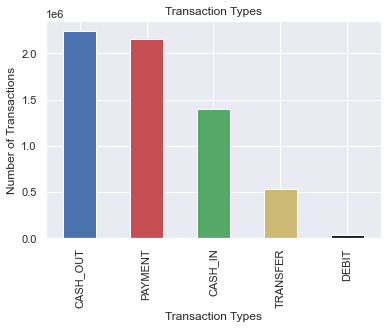

On computing the number of fraud transactions grouped by the transaction type, I noticed that only `CASH_OUT` and `TRANSFER` have the fraudulent transaction. So in order to reduce the search space, I discareded other type of payment modes (however, the downside is that, this assumption constrained on the Type is based on given data alone).

```
type      isFraud
CASH_IN   0          1399284
CASH_OUT  0          2233384
          1             4116
DEBIT     0            41432
PAYMENT   0          2151495
TRANSFER  0           528812
          1             4097
dtype: int64
```

Finally my dataset is reduced to these transaction types, as shown below.

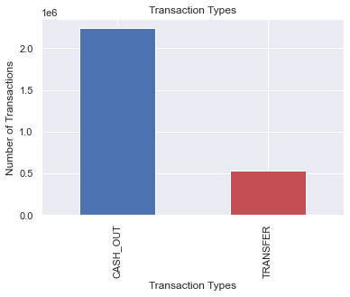

# Section 3: Inconsistency

The odd one out is clearly "isFlaggedFraud", with no pattern or explanation for the behavior in the dataset. There is a total of 16 such transactions for which this attribute is set. As per the description given in this value is set for transactions that involve an amount above 200,000. However by simply finding the maximum amount one could refute the given description.

`Min flagged transaction amount: 353874.22 Max flagged transaction amount: 10000000.0`

# Section 4: Pairplot Comparision

To create the paiplot, I have used a subset of the data, which includes all the fraudulent transactions and 10,000 non-fraud transactions concatinated together (this is done for the ease of analysis and space constraints) Few interesting inferences made on the basis of the paiplot: ```1. Step vs Amount: There is a clear distinction in terms of how spread out fradulent transactionas are compared to non-fraud.

1. Amount vs Balance at Dest/Origin: We can see that the fraudulent transactions have a much greater amount compared non--fraud.
2. newbalanceOrig vs oldbalanceOrg: There is somewhat linear separtion, although some overlap```

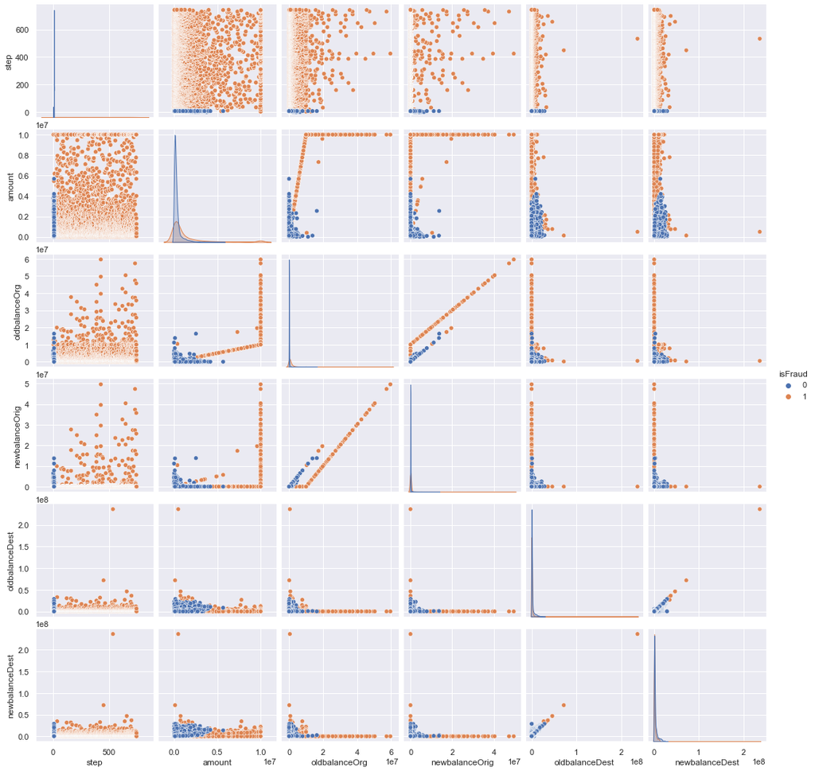

# Section 5: Feature Engineering: Net Balance doesn't tally after transaction

This is a rather important pattern, as shown by the pie chart, that almost half i.e. `49.6%` the fraudulent transactions have a disparity bretween the net balance not adding up. On the other hand that is not the case for non-fraud transactions at `0.1%`. This idea is used to compute a new feature, that is the difference between the accounts + the amount being transfered. This is stored in the form of `balanceDiffOrg` and `balanceDiffDest`.

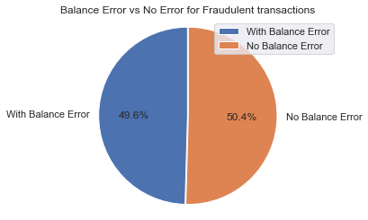

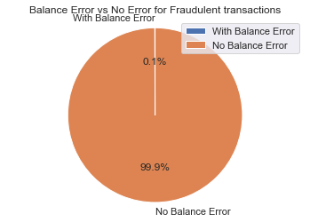

The boxplot diagram below also gives the pictorial representation of discrepancies in the net balance for fraudulent transactions.

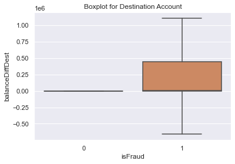

# Section 6: Correlation Matrix

I iteratively eliminated one of the attributes for a given pair that has a red block. For example, I trained my model by dropping newBalanceDest as it correlates with `Amount`, similarly for all the pairs. But observed that that the correlation although present to some extent, removing those attributes lead to the decrease in ROC scores. Hence I finally removed only those attributes which are unique like the `nameOrig and nameDest`. Also dropped `isFlaggedFraud` due to reasons explained above. The boxplot diagram above also gives the pictorial representation of discrepancies in the net balance for fraudulent transactions.

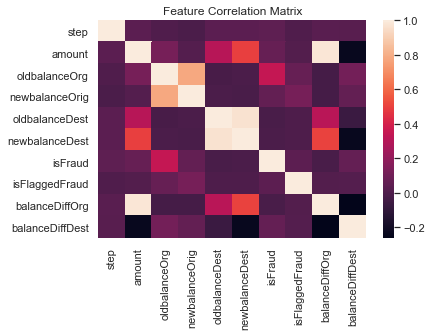

# Section 7: Training

Training was done on `Gradient boosting` as the baseline, and then the second model used is `XGBoost` with parameter tuning using `Grid search`. The ROC score for baseline Gradient boositng is: `0.748`. In the next section I will cover more on the second algorithm and its results.

### Section 7.1: XGBoost and Grid Search for Parameter Tuning

My go to algorithm for kaggle competitions is xgboost, as its a great combination of ensemble algorithm, and that too with paralization.

Grid Search: As shown below in the code snippet, I focus on 3 important parameters, `max_depth, gamma and scale_pos_weights`.

1. max_dept: refers to maximum depth of tree
2. gamma: control regularization (0 means no regularization)
3. scale_pos_weights: This is important handle class imbalance, as mentioned above. In this case I uses the ration of class weights.

```
params = {'max_depth':range(4), 'gamma':(0.1, 0.2, 0), 'max_depth':range(5)}
grid = GridSearchCV(estimator = XGBClassifier(scale_pos_weight = weights, n_jobs = 4),
                        param_grid = params, scoring='roc_auc', n_jobs=4, iid=False, cv=5)
grid.fit(trainX,trainY)

Best params: ({'gamma': 0.1, 'max_depth': 1}, 0.9989555742451716)
```

## Section 7.2: ROC Plot for XGboost

The important thing to understand is that class imbalance is huge, hence one can't directly use accuracy as a parameter to judge the model. Since if the classifier simply predict everything as `non-fraud` then the accuracy would still be 99.8% i.e. the total proportion of the non-fraud in the dataset. Hence AUC score/ROC plots are a better judge of the model. A value of 1 means great, 0.5 means as good as a coin toss.

```
AUPRC = 0.9965450949867087
```

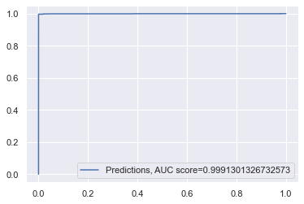